# Animal Tracking Toolbox Quick Guide

MCP polygons and probability distributions associated with fKUD and BBKUDs can be stored when `storepoly = TRUE`. This outputs a list object with the two components, `$Overall`: a tibble data frame with activity space metrics for the full period of the tag and `$Subsetted`: a tibble data frame with activity space metrics for weekly or monthly temporal subsets depending on the `sub` argument, but also includes an additional `$Spatial.Objects` list that stores polygons (if calculating MCPs) or probability distribution raster (if calculating fKUD or BBKUD) for full tag life and temporal subsets.

```ruby
## Estimate 20%, 50% and 95% Brownian Bridge Kernel Utilisation Distribution ('BBKUD') contour areas and store polygons
BBkud_est<-HRSummary(COAdata,
                   projCRS=proj,
                   type="BBKUD",
                   cont=c(20,50,95),
                   storepoly=TRUE)

summary(BBkud_est)
                Length Class  Mode
Overall         12     tbl_df list
Subsetted       13     tbl_df list
Spatial.Objects 11     -none- list
```

The `$Spatial.Objects` list object in itself consists of a nested list. The example object above, `BBkud_est` is structured in this way:

[output not shown]

Each raster object or raster stack can be plotted and manipulated using the `raster` library

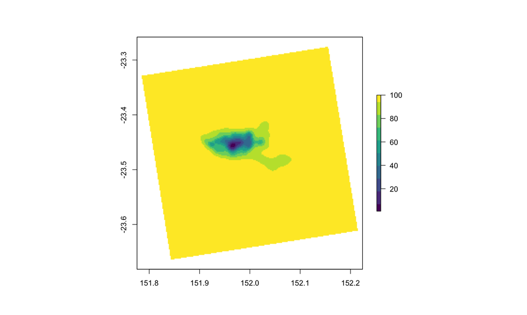

```ruby
library(raster)
library(viridis) ## access more color palettes!

## Lets plot the overall BBKUD for Tag.ID `77523307`
plot(BBkud_est
     $ Spatial.Objects
     $ `77523307`
     $ BBKUD_full,
     col=viridis(10))
```

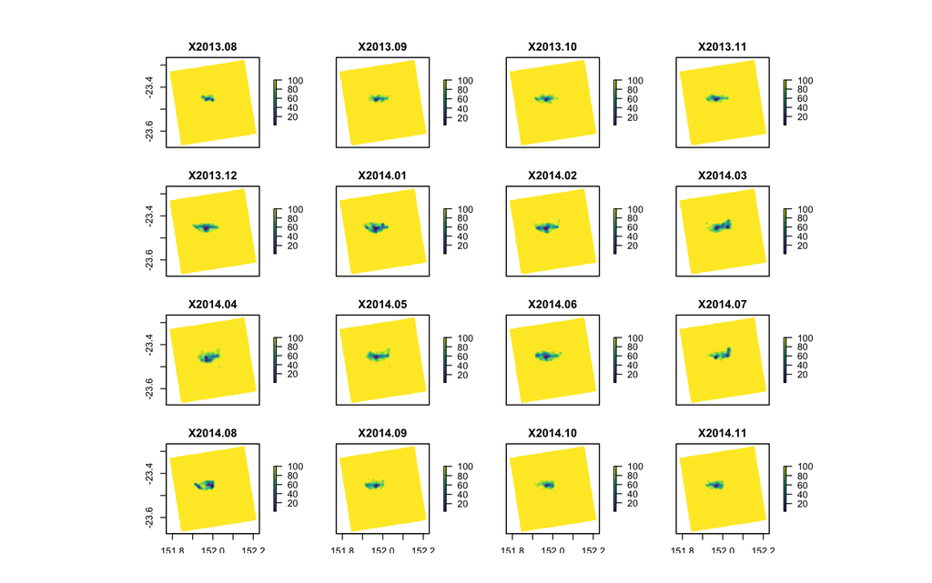

```ruby
## We can also plot the raster stack for all temporal subsets for Tag.ID `77523307`
plot(BBkud_est
     $ Spatial.Objects
     $ `77523307`
     $ BBKUD_sub,
     col=viridis(10))
```

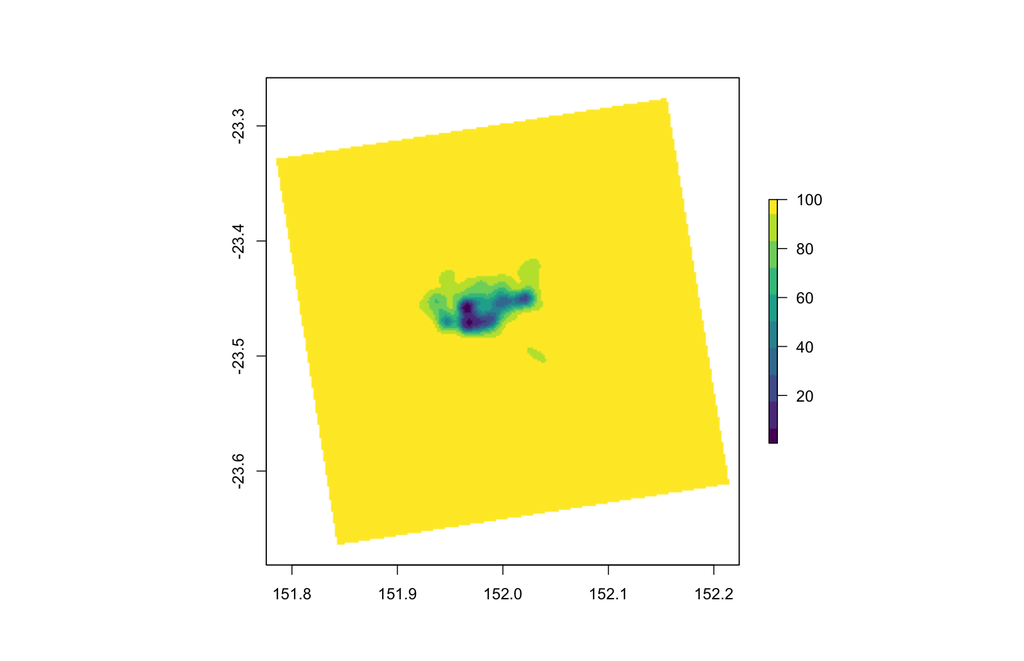

```ruby
## If we want to see what our animal is doing in April 2014
plot(BBkud_est
     $ Spatial.Objects
     $ `77523307`
     $ BBKUD_sub
     $ X2014.04,
     col=viridis(10))
```

*More functions to visualise standardised metrics coming soon!!*

# Authors

Vinay Udyawer  
v.udyawer@aims.gov.au  
Australian Institute of Marine Science

Ross Dwyer  
ross.dwyer@uq.edu.au  
University of Queensland

Xavier Hoenner  
xavier.hoenner@utas.edu.au  
Australian Ocean Data Network

**Vignette version** 1.0.2 (28 Nov 2018)